# Chapter 2: Statistical Inference - Problem Set

## 4.3 Hypothesis Test 3: Paired T-Test

Assume we want to know if there is an effect of two settings (e.g., System A or System B) on the result (Y) of a simulation. We want to test the results in a random variety of environmental conditions (e.g., starting positions), but know that these starting locations can have an effect on Y, therefore we decide to test each setting in each initial starting condition, so that we get results that look Chap2_DataSet.csv.

Do the following:

- Plot the data and make any general observations.
- Conduct a paired T-Test and assess the results for confidence at the 90% confidence level.
- Identify the assumptions / conditions you are using that make a paried t test appropriate.

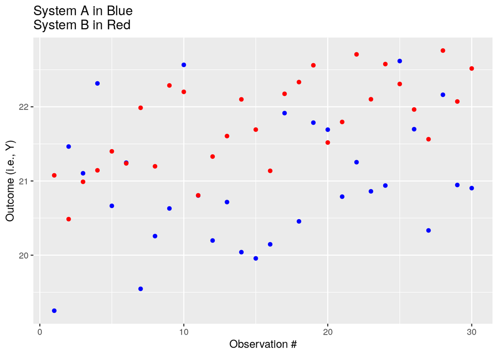

```r
# First read the data
myData <- read.csv('Chap2_DataSet.csv', header = T, sep = ',', stringsAsFactors = F)

# second, its a good idea to look at the data
ggplot(myData) +
  geom_point(aes(x = Condition, y = System.A), color = 'blue') +
  geom_point(aes(x = Condition, y = System.B), color = 'red') +
  xlab('Observation #') + ylab('Outcome (i.e., Y)') + ggtitle('System A in Blue\nSystem B in Red')
```

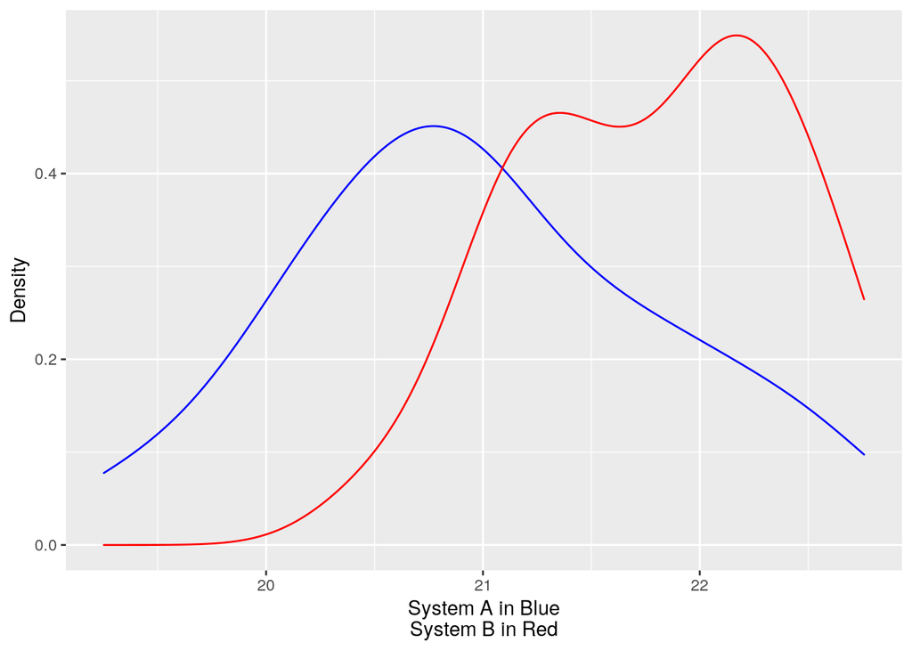

```r
# We see at least two things:
# 1) There may be a slight general trend upward with increasing sample size
# 2) It looks like System B generally has a higher Y value, though 1) not always and 2) it is not clear

# We have two sets of data that are approximately normal (we can see this graphically or through using a Shapiro Wilk Test
ggplot(myData) +
  geom_density(aes(x = System.A), color = 'blue') +
  geom_density(aes(x = System.B), color = 'red') +
  xlab('System A in Blue\nSystem B in Red') + ylab('Density')
```

```r
# They are paired as described above, therefore it makes sense to do a paired T Test

t.test(myData$System.A, myData$System.B, paired = T)
```

```
##
##  Paired t-test
##
## data:  myData$System.A and myData$System.B
## t = -4.8985, df = 29, p-value = 3.363e-05
## alternative hypothesis: true difference in means is not equal to 0
## 95 percent confidence interval:
##  -1.1511520 -0.4730271
## sample estimates:
## mean of the differences
##              -0.8120896
```

```r
# The paired T test has a p-value of ~0, so we reject the null that the two systems produce the same Y value (i.e., the difference in results is 0 for each pair).
# We can say this as:
# 1) we have a paired situation -- each of our two observations come from the same environmental considerations for each replicate.
# 2) They do produce different means (i.e. the difference in their means is not 0), so the system choice has some effect, which is estimated to be ~ .8 on average.
```

## 4.4 Hypothesis Test 4: Learning Hypothesis Tests

Look up **one** of the following tests and do the following:

1. Provide a brief description.
2. Clearly articulate the null and alternative hypothesis.
3. Explain any underlying assumptions, requirements, etc. for using the test.
4. Explain how to implement this test in *R*.
5. Provide a brief example. You can use the Ames, IA data set, synthesize a data set using a random number generator, or include some other data set.
6. Include anything else you think is pertinent.

Tests:

1. Either of the Wilcoxon Tests (Rank Sum, Signed Rank)
2. Z Test for Large Sample Proportions (1 or 2 proprotions)
3. Bartlett Test of Variances
4. Fisher Test of Independence
5. Poisson Test (comparison of rates from Poisson distributions)
6. Kolmogorov Smirnov Test of Distribution Fit
7. Your favorite hypothesis test that I didn’t write here.

```r
# Answers here will vary significantly.  I'm working to build examples for all the tests, but this may take a while to build them all.
```